# Simulation check of the placebo test

BIS 527: does the pipeline find a neighbor effect we planted?

2026-10-29

Before trusting the placebo test on the real data, we check it on data where we know the answer. We keep everything real (the 450 regions, the border network, births, states, the 2013 starting rates) and simulate the case counts from M1 with a neighbor effect γ that we choose:

- **γ = 0:** no neighbor effect. The real network should beat its placebos (rank p ≤ 0.05) only about 5% of the time. Much more often would mean the test is too easy.
- **γ = 0.04:** about the size we estimate on the real data.
- **γ = 0.10:** a strong effect.

Each simulated dataset goes through the same steps as the real analysis (`border_network.Rmd`, Sections 6 and 7): M0, M1 with the real border network, M1 with 19 new within-state placebos, then T and the rank p’s.

Inputs: `data/shared/region_panel.csv` and the network files that `border_network.Rmd` writes to `data/shared/networks_r/` (knit that first). The simulation takes a while (about 10 minutes on 4 cores for 3 × 100 replicates), so its results are saved to `data/shared/results_r/simulation_check.csv` and read back on later knits. Set `rerun: true` to run it again.

```r
library(dplyr)
library(MASS, exclude = "select")
```

## 1. Data and the border network

```r
nodes <- read.csv(file.path(params$networks_dir, "nodes.csv"),
                  colClasses = c(health_region = "character"))
edges <- read.csv(file.path(params$networks_dir, "edges_border.csv"),
                  colClasses = "character")
codes <- nodes$health_region
uf <- nodes$uf
n <- length(codes)
if (n != 450) stop("nodes.csv has ", n, " regions, not 450: re-knit border_network.Rmd first")

A <- matrix(0, n, n, dimnames = list(codes, codes))
A[cbind(match(edges$region_i, codes), match(edges$region_j, codes))] <- 1
A <- A + t(A)
stopifnot(isSymmetric(A), all(rowSums(A) > 0))
W <- A / rowSums(A)

region_panel <- read.csv("data/shared/region_panel.csv",
                         colClasses = c(health_region = "character")) |>
  filter(health_region %in% codes, year >= 2013, year <= 2022) |>
  mutate(x = log1p(1000 * Y / B))
years <- 2013:2022
# The saved networks and the panel must cover the same health regions.
stopifnot(setequal(unique(region_panel$health_region), codes))

# Births as a region x year matrix, in node order.
births <- matrix(NA_real_, n, length(years), dimnames = list(codes, years))
births[cbind(match(region_panel$health_region, codes),
             match(region_panel$year, years))] <- region_panel$B
stopifnot(!anyNA(births), all(births > 0))
c(regions = n, border_links = sum(A) / 2)
```

```
##      regions border_links
##          450         1248
```

## 2. Model functions

These are the functions from `border_network.Rmd` (Sections 6 and 7), changed only to take the panel as an argument.

```r
make_placebo <- function(A, uf, seed) {
  set.seed(seed)
  perm <- seq_along(uf)
  for (s in unique(uf)) {
    idx <- which(uf == s)
    perm[idx] <- idx[sample.int(length(idx))]
  }
  A_p <- A[perm, perm]
  dimnames(A_p) <- dimnames(A)
  A_p
}

model_data <- function(panel, W) {
  i <- match(panel$health_region, rownames(W))
  j <- match(panel$year, years)
  x <- matrix(NA_real_, nrow(W), length(years))
  x[cbind(i, j)] <- panel$x
  lag <- cbind(NA, x[, -length(years)])
  nbr <- W %*% lag
  d <- panel |>
    mutate(own_lag = lag[cbind(i, j)], nbr = nbr[cbind(i, j)],
           trend = year - 2014) |>
    filter(year >= 2014)
  train <- d$year <= 2021
  d$Z <- (d$nbr - mean(d$nbr[train])) / sd(d$nbr[train])
  d
}

birth_weighted_rmse <- function(Y, B, pred) {
  sqrt(sum(B * (1000 * pred / B - 1000 * Y / B)^2) / sum(B))
}

fit_predict <- function(panel, W, with_z) {
  d <- model_data(panel, W)
  f <- if (with_z) {
    Y ~ own_lag + Z + uf + trend + offset(log(B))
  } else {
    Y ~ own_lag + uf + trend + offset(log(B))
  }
  train <- d[d$year <= 2021, ]
  test <- d[d$year == 2022, ]
  fit <- glm.nb(f, data = train)
  pred <- predict(fit, newdata = test, type = "response")
  list(fit = fit,
       score = birth_weighted_rmse(test$Y, test$B, pred),
       gamma = if (with_z) unname(coef(fit)["Z"]) else NA)
}

rank_p <- function(real, null) (1 + sum(null >= real)) / (1 + length(null))
```

## 3. Parameters for the simulation

The simulation uses the coefficients of M1 fitted to the real data with the border network, except γ, which we set. Z is standardized with the real data’s training mean and SD, so γ means the same thing as in the real analysis (per SD of the neighbors’ lagged rate).

```r
real_fit <- fit_predict(region_panel, W, TRUE)$fit
b <- coef(real_fit)
theta <- real_fit$theta

real_d <- model_data(region_panel, W)
z_mean <- mean(real_d$nbr[real_d$year <= 2021])
z_sd <- sd(real_d$nbr[real_d$year <= 2021])

state_effect <- setNames(rep(0, length(unique(uf))), sort(unique(uf)))
for (s in names(state_effect)[-1]) state_effect[s] <- b[[paste0("uf", s)]]

c(intercept = b[["(Intercept)"]], own_lag = b[["own_lag"]],
  real_gamma = b[["Z"]], trend = b[["trend"]], theta = theta)
```

```
##    intercept      own_lag   real_gamma        trend        theta
## -6.702078257  0.890746381  0.039638979 -0.001476097  5.922313340
```

## 4. Simulating case counts

Start from the real 2013 rates. For each year t from 2014 to 2022: own_lag = x in year t − 1, Z = the standardized neighbor average of own_lag, μ = B · exp(intercept + β own_lag + γ Z + state + δ trend), and Y ~ negative binomial(μ, θ). Then x for year t is computed from the simulated Y, so each year feeds the next, through the region itself and through its neighbors.

```r
simulate_panel <- function(gamma, seed) {
  set.seed(seed)
  x <- matrix(NA_real_, n, length(years))
  y <- matrix(NA_real_, n, length(years))
  start <- region_panel[region_panel$year == 2013, ]
  x[match(start$health_region, codes), 1] <- start$x
  y[match(start$health_region, codes), 1] <- start$Y
  for (k in 2:length(years)) {
    own_lag <- x[, k - 1]
    z <- (as.vector(W %*% own_lag) - z_mean) / z_sd
    eta <- b[["(Intercept)"]] + b[["own_lag"]] * own_lag + gamma * z +
      state_effect[uf] + b[["trend"]] * (years[k] - 2014)
    mu <- births[, k] * exp(eta)
    y[, k] <- rnbinom(n, size = theta, mu = mu)
    x[, k] <- log1p(1000 * y[, k] / births[, k])
  }
  data.frame(health_region = rep(codes, length(years)),
             uf = rep(uf, length(years)),
             year = rep(years, each = n),
             Y = as.vector(y), B = as.vector(births), x = as.vector(x))
}

# Sanity check: do simulated data look like the real data? 20 simulated
# datasets per gamma, compared with the real data year by year.
by_year <- function(d) {
  d |> group_by(year) |>
    summarise(rate = 1000 * sum(Y) / sum(B), zero_share = mean(Y == 0),
              .groups = "drop")
}
real_by_year <- by_year(region_panel)
sim_by_year <- do.call(rbind, lapply(params$gammas, function(g) {
  do.call(rbind, lapply(1:20, function(r)
    by_year(simulate_panel(g, 9e6 + r)) |> mutate(gamma = g)))
})) |>
  group_by(gamma, year) |>
  summarise(rate = mean(rate), zero_share = mean(zero_share),
            .groups = "drop")

rate_table <- real_by_year |> select(year, real = rate)
for (g in params$gammas) {
  rate_table[[paste0("sim_gamma_", g)]] <-
    sim_by_year$rate[sim_by_year$gamma == g]
}
knitr::kable(rate_table, digits = 2,
             caption = "Rate per 1,000 births: real vs. simulated (mean of 20)")
```

Rate per 1,000 births: real vs. simulated (mean of 20)

| year | real | sim_gamma_0 | sim_gamma_0.04 | sim_gamma_0.1 |
| --- | --- | --- | --- | --- |
| 2013 | 4.86 | 4.86 | 4.86 | 4.86 |
| 2014 | 5.54 | 5.43 | 5.48 | 5.28 |
| 2015 | 6.60 | 5.96 | 5.87 | 5.72 |
| 2016 | 7.54 | 6.30 | 6.32 | 6.52 |
| 2017 | 8.68 | 6.47 | 6.75 | 7.22 |
| 2018 | 9.12 | 6.72 | 7.04 | 8.03 |
| 2019 | 8.91 | 6.79 | 7.50 | 8.86 |
| 2020 | 8.60 | 6.82 | 7.73 | 9.37 |
| 2021 | 10.13 | 6.98 | 7.91 | 10.37 |
| 2022 | 10.36 | 6.99 | 8.28 | 11.77 |

```r
zero_table <- real_by_year |>
  filter(year >= 2014) |>
  summarise(real = mean(zero_share))
for (g in params$gammas) {
  zero_table[[paste0("sim_gamma_", g)]] <-
    mean(sim_by_year$zero_share[sim_by_year$gamma == g & sim_by_year$year >= 2014])
}
knitr::kable(zero_table, digits = 3,
             caption = "Share of region-years with zero cases, 2014-2022")
```

Share of region-years with zero cases, 2014-2022

| real | sim_gamma_0 | sim_gamma_0.04 | sim_gamma_0.1 |
| --- | --- | --- | --- |
| 0.04 | 0.025 | 0.027 | 0.029 |

- The simulation starts on track and then falls behind. M1 says each year mostly carries over from the last one (0.89), with almost *no trend* of its own. When we fit to real data, every year starts from the *real previous year*, so the model keeps up. A simulation that runs on its own compounds only what the model knows, so it levels off around 7. The real rise from 5 to 10 came from nationwide pushes year after year that M1 doesn’t explain. *Fixed year effects would capture those.*
- *Neighbors amplify*. With γ = 0.10 the simulated rate climbs much faster, because high-rate regions push their neighbors up, and those neighbors push back. *γ = 0.04 still falls short of the real rise*, so neighbors alone don’t explain the national trend.
- The real data have *more zero-case region-years (4.0% vs about 2.7%)*. Some regions sit lower than their state effect allows, which suggests *region-level differences M1 doesn’t model*

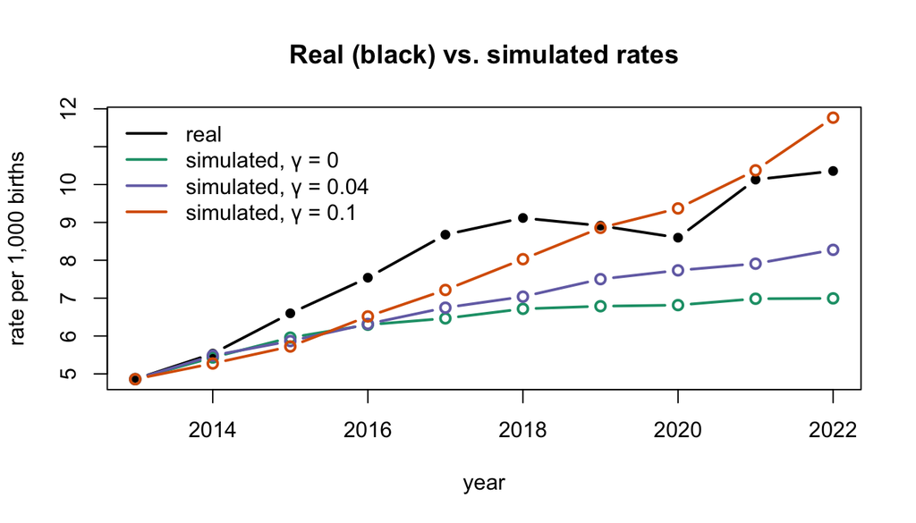

```r
cols <- c("#1b9e77", "#7570b3", "#d95f02")
plot(real_by_year$year, real_by_year$rate, type = "b", pch = 16, lwd = 2,
     ylim = range(c(real_by_year$rate, sim_by_year$rate)),
     xlab = "year", ylab = "rate per 1,000 births",
     main = "Real (black) vs. simulated rates")
for (k in seq_along(params$gammas)) {
  s <- sim_by_year[sim_by_year$gamma == params$gammas[k], ]
  lines(s$year, s$rate, type = "b", col = cols[k], lwd = 2)
}
legend("topleft", c("real", paste("simulated, γ =", params$gammas)),
       col = c("black", cols), lwd = 2, bty = "n")
```

## 5. Running the pipeline on simulated data

One replicate: simulate, fit M0 and M1 (real border network), then M1 with 19 placebos made with new seeds for that replicate.

```r
one_replicate <- function(gamma, rep) {
  seed <- round(gamma * 1e4) * 1e5 + rep * 100
  panel <- simulate_panel(gamma, seed)
  m0 <- fit_predict(panel, W, FALSE)$score
  m1 <- fit_predict(panel, W, TRUE)
  null <- t(sapply(seq_len(params$n_placebos), function(k) {
    A_p <- make_placebo(A, uf, seed + k)
    r <- fit_predict(panel, A_p / rowSums(A_p), TRUE)
    c(T = m0 - r$score, gamma = r$gamma)
  }))
  data.frame(true_gamma = gamma, rep = rep,
             gamma_hat = m1$gamma, T = m0 - m1$score,
             placebo_gamma_mean = mean(null[, "gamma"]),
             placebo_T_mean = mean(null[, "T"]),
             gamma_rank_p = rank_p(m1$gamma, null[, "gamma"]),
             T_rank_p = rank_p(m0 - m1$score, null[, "T"]))
}
```

```r
sim_file <- file.path(params$results_dir, "simulation_check.csv")
if (params$rerun || !file.exists(sim_file)) {
  grid <- expand.grid(rep = seq_len(params$n_reps), gamma = params$gammas)
  cores <- if (.Platform$OS.type == "windows") 1 else params$cores
  started <- Sys.time()
  sims <- parallel::mclapply(seq_len(nrow(grid)), function(r) {
    one_replicate(grid$gamma[r], grid$rep[r])
  }, mc.cores = cores)
  failed <- !sapply(sims, is.data.frame)
  if (any(failed)) warning(sum(failed), " replicates failed and are dropped")
  sims <- do.call(rbind, sims[!failed])
  dir.create(params$results_dir, showWarnings = FALSE, recursive = TRUE)
  write.csv(sims, sim_file, row.names = FALSE)
  message("simulation took ", format(Sys.time() - started))
}
sims <- read.csv(sim_file)
table(true_gamma = sims$true_gamma)
```

```
## true_gamma
##    0 0.04  0.1
##  100  100  100
```

## 6. Results

```r
sims |>
  group_by(true_gamma) |>
  summarise(replicates = n(),
            mean_gamma_hat = mean(gamma_hat),
            sd_gamma_hat = sd(gamma_hat),
            mean_placebo_gamma = mean(placebo_gamma_mean),
            gamma_reject_rate = mean(gamma_rank_p <= 0.05),
            mean_T = mean(T),
            T_positive = mean(T > 0),
            T_reject_rate = mean(T_rank_p <= 0.05)) |>
  knitr::kable(digits = 3, caption = sprintf(
    "%d placebos per replicate; reject rate = share of replicates with rank p <= 0.05",
    params$n_placebos))
```

19 placebos per replicate; reject rate = share of replicates with rank p <= 0.05

| true_gamma | replicates | mean_gamma_hat | sd_gamma_hat | mean_placebo_gamma | gamma_reject_rate | mean_T | T_positive | T_reject_rate |
| --- | --- | --- | --- | --- | --- | --- | --- | --- |
| 0.00 | 100 | -0.009 | 0.011 | -0.010 | 0.08 | 0.002 | 0.50 | 0.03 |
| 0.04 | 100 | 0.027 | 0.013 | -0.005 | 0.83 | -0.007 | 0.60 | 0.35 |
| 0.10 | 100 | 0.091 | 0.013 | -0.001 | 1.00 | 0.066 | 0.58 | 0.51 |

How to read it:

- **mean_gamma_hat:** M1 should recover the γ we planted.
- **mean_placebo_gamma:** if this is negative even when the true γ is 0, the negative placebo γ in the real analysis comes from the setup, not from the data.
- **gamma_reject_rate:** the share of replicates where the test rejects “no neighbor effect”, i.e. the γ rank p is 0.05 or less (the real network’s γ is above all 19 placebos). At γ = 0 this is the false positive rate and should be near 0.05; at γ > 0 it is the test’s power.
- **T_positive:** the share of replicates where M1 predicts 2022 better than M0 (T > 0).
- **T_reject_rate:** the same as gamma_reject_rate, for T. If T_positive and T_reject_rate stay low even at γ = 0.10, T cannot detect a neighbor effect of a realistic size, and the real data’s T result says little.

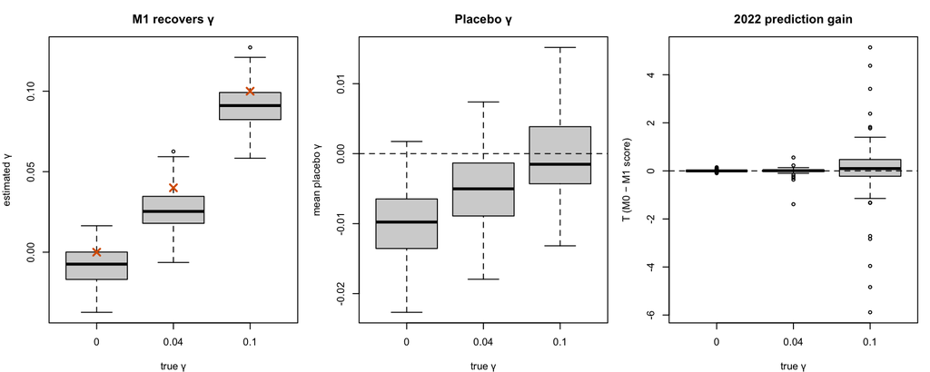

```r
op <- par(mfrow = c(1, 3), mar = c(4, 4, 3, 1))
boxplot(gamma_hat ~ true_gamma, sims, xlab = "true γ", ylab = "estimated γ",
        main = "M1 recovers γ")
points(seq_along(params$gammas), params$gammas, pch = 4, col = "#d95f02",
       lwd = 2, cex = 1.5)
boxplot(placebo_gamma_mean ~ true_gamma, sims, xlab = "true γ",
        ylab = "mean placebo γ", main = "Placebo γ")
abline(h = 0, lty = 2)
boxplot(T ~ true_gamma, sims, xlab = "true γ", ylab = "T (M0 − M1 score)",
        main = "2022 prediction gain")
abline(h = 0, lty = 2)
```

```r
par(op)
```

Gamma: Question Do the real neighbors’ past rates fit better than shuffled neighbors?  
T stat: Do the real neighbors predict 2022 better than shuffled neighbors?

Calibration in detail: with no neighbor effect, the γ rank p should be spread evenly over 0.05, 0.10, …, 1.

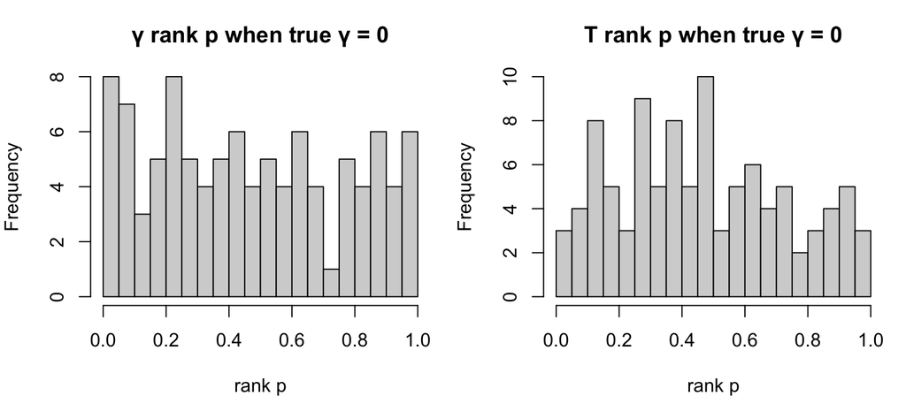

```r
op <- par(mfrow = c(1, 2), mar = c(4, 4, 3, 1))
null_sims <- sims[sims$true_gamma == 0, ]
hist(null_sims$gamma_rank_p, breaks = seq(0, 1, 0.05),
     main = "γ rank p when true γ = 0", xlab = "rank p")
hist(null_sims$T_rank_p, breaks = seq(0, 1, 0.05),
     main = "T rank p when true γ = 0", xlab = "rank p")
```

```r
par(op)
```

## 7. What this means for the real analysis

```r
f <- sims |>
  group_by(true_gamma) |>
  summarise(bias = mean(gamma_hat) - first(true_gamma),
            placebo_gamma = mean(placebo_gamma_mean),
            gamma_power = mean(gamma_rank_p <= 0.05),
            T_power = mean(T_rank_p <= 0.05))
f
```

```
## # A tibble: 3 × 5
##   true_gamma     bias placebo_gamma gamma_power T_power
##        <dbl>    <dbl>         <dbl>       <dbl>   <dbl>
## 1       0    -0.00891     -0.0101          0.08    0.03
## 2       0.04 -0.0131      -0.00535         0.83    0.35
## 3       0.1  -0.00868     -0.000535        1       0.51
```

```r
g0 <- f[f$true_gamma == 0, ]
g4 <- f[f$true_gamma == 0.04, ]
```

- **Calibration.** With no neighbor effect, the real network’s γ beat all 19 placebos in 8% of replicates, and T in 3% (expected: 5%; with 100 replicates, anything from about 1% to 9% is consistent with that). So the within-state placebo test is not too easy here.
- **Power.** With γ = 0.04, about the size we estimate, the γ test found the effect in 83% of replicates, but the T test only in 35%. So a real effect of our size usually shows up in γ and usually does not show up in the 2022 prediction. The real data’s pattern (γ beats all placebos, T does not) is what we would expect if the effect is real but small.
- **Negative placebo γ.** Even with no neighbor effect, the estimated γ is biased down by about 0.009, and the placebo γ average -0.010. Part of the negative placebo γ in the real analysis (about −0.03) comes from the setup itself; the rest is something in the real data the simulation does not have.
- **Limit of the simulation.** The simulated rates rise less than the real ones (Section 4). In the real fit, the trend is about zero and the own_lag coefficient is below 1, so a simulation left to run on its own settles toward a lower level; the real rise came from nationwide shocks year after year that M1 does not model. The real data also have more region-years with zero cases than the simulation, so some regions differ from their state more than M1 assumes. The simulation tests the pipeline under M1’s own assumptions, not every way the real data could differ.

## 8. Cross check: can we tell border from k-NN?

The real analysis compares two networks: border and k-NN. Sections 5–7 show the placebo test works when we analyze with the network that generated the data. Here we ask whether the two networks can be told apart. We simulate data from each network and analyze each dataset with both:

|  | analyze with border | analyze with k-NN |
| --- | --- | --- |
| **generate with border** | right network | closeness only |
| **generate with k-NN** | border only | right network |

For each simulated dataset we fit M0, M1 with border, M1 with k-NN, and 19 placebos of each network, and record each network’s γ and rank p. We also compare the two M1 fits head to head by AIC (lower is better), which is how we would choose between them on the real data.

Data generated with k-NN use the coefficients of M1 fitted to the real data with k-NN (and that fit’s Z mean and SD), so each network generates data the way it would explain the real data. The results are saved to `data/shared/results_r/simulation_cross.csv`; set `rerun_cross: true` to run again (about 45 minutes on 4 cores).

```r
edges_knn <- read.csv(file.path(params$networks_dir, "edges_knn.csv"),
                      colClasses = "character")
A_knn <- matrix(0, n, n, dimnames = list(codes, codes))
A_knn[cbind(match(edges_knn$region_i, codes),
            match(edges_knn$region_j, codes))] <- 1
A_knn <- A_knn + t(A_knn)
stopifnot(isSymmetric(A_knn), all(rowSums(A_knn) > 0))
W_knn <- A_knn / rowSums(A_knn)

# Simulation parameters from the real M1 fit with a given network.
sim_params <- function(W) {
  fit <- fit_predict(region_panel, W, TRUE)$fit
  b <- coef(fit)
  d <- model_data(region_panel, W)
  st <- setNames(rep(0, length(unique(uf))), sort(unique(uf)))
  for (s in names(st)[-1]) st[s] <- b[[paste0("uf", s)]]
  list(W = W, b = b, theta = fit$theta, state = st,
       z_mean = mean(d$nbr[d$year <= 2021]), z_sd = sd(d$nbr[d$year <= 2021]),
       aic = AIC(fit))
}
pars <- list(border = sim_params(W), knn = sim_params(W_knn))

# Shared links: how similar are the two networks?
c(border_links = sum(A) / 2, knn_links = sum(A_knn) / 2,
  shared_links = sum(A == 1 & A_knn == 1) / 2)
```

```
## border_links    knn_links shared_links
##         1248         1339         1024
```

```r
sapply(pars, function(p) c(own_lag = p$b[["own_lag"]], gamma = p$b[["Z"]],
                           theta = p$theta, aic = p$aic))
```

```
##               border          knn
## own_lag 8.907464e-01 8.910212e-01
## gamma   3.963898e-02 4.000057e-02
## theta   5.922313e+00 5.917407e+00
## aic     2.513410e+04 2.513426e+04
```

The same simulation as Section 4, but with a chosen network’s neighbors and parameters. With border parameters it gives exactly the datasets of `simulate_panel()` for the same seed.

```r
simulate_with <- function(p, gamma, seed) {
  set.seed(seed)
  x <- matrix(NA_real_, n, length(years))
  y <- matrix(NA_real_, n, length(years))
  start <- region_panel[region_panel$year == 2013, ]
  x[match(start$health_region, codes), 1] <- start$x
  y[match(start$health_region, codes), 1] <- start$Y
  for (k in 2:length(years)) {
    own_lag <- x[, k - 1]
    z <- (as.vector(p$W %*% own_lag) - p$z_mean) / p$z_sd
    eta <- p$b[["(Intercept)"]] + p$b[["own_lag"]] * own_lag + gamma * z +
      p$state[uf] + p$b[["trend"]] * (years[k] - 2014)
    y[, k] <- rnbinom(n, size = p$theta, mu = births[, k] * exp(eta))
    x[, k] <- log1p(1000 * y[, k] / births[, k])
  }
  data.frame(health_region = rep(codes, length(years)),
             uf = rep(uf, length(years)),
             year = rep(years, each = n),
             Y = as.vector(y), B = as.vector(births), x = as.vector(x))
}
stopifnot(identical(simulate_with(pars$border, 0.04, 1),
                    simulate_panel(0.04, 1)))

nets <- list(border = A, knn = A_knn)

cross_replicate <- function(generator, gamma, rep) {
  seed <- round(gamma * 1e4) * 1e5 + rep * 100 +
    if (generator == "knn") 5e7 else 0
  panel <- simulate_with(pars[[generator]], gamma, seed)
  m0 <- fit_predict(panel, W, FALSE)$score
  out <- data.frame(generator = generator, true_gamma = gamma, rep = rep)
  for (nm in names(nets)) {
    A_n <- nets[[nm]]
    m1 <- fit_predict(panel, A_n / rowSums(A_n), TRUE)
    null <- t(sapply(seq_len(params$n_placebos), function(k) {
      A_p <- make_placebo(A_n, uf, seed + k + if (nm == "knn") 50 else 0)
      r <- fit_predict(panel, A_p / rowSums(A_p), TRUE)
      c(T = m0 - r$score, gamma = r$gamma)
    }))
    out[[paste0("gamma_hat_", nm)]] <- m1$gamma
    out[[paste0("aic_", nm)]] <- AIC(m1$fit)
    out[[paste0("T_", nm)]] <- m0 - m1$score
    out[[paste0("gamma_rank_p_", nm)]] <- rank_p(m1$gamma, null[, "gamma"])
    out[[paste0("T_rank_p_", nm)]] <- rank_p(m0 - m1$score, null[, "T"])
  }
  out
}
```

```r
cross_file <- file.path(params$results_dir, "simulation_cross.csv")
if (params$rerun_cross || !file.exists(cross_file)) {
  grid <- expand.grid(rep = seq_len(params$n_reps_cross),
                      gamma = params$cross_gammas,
                      generator = names(nets), stringsAsFactors = FALSE)
  cores <- if (.Platform$OS.type == "windows") 1 else params$cores
  started <- Sys.time()
  cross <- parallel::mclapply(seq_len(nrow(grid)), function(r) {
    cross_replicate(grid$generator[r], grid$gamma[r], grid$rep[r])
  }, mc.cores = cores)
  failed <- !sapply(cross, is.data.frame)
  if (any(failed)) warning(sum(failed), " replicates failed and are dropped")
  cross <- do.call(rbind, cross[!failed])
  write.csv(cross, cross_file, row.names = FALSE)
  message("cross check took ", format(Sys.time() - started))
}
cross <- read.csv(cross_file)
table(generator = cross$generator, true_gamma = cross$true_gamma)
```

```
##          true_gamma
## generator   0 0.04
##    border 100  100
##    knn    100  100
```

```r
cross |>
  group_by(generator, true_gamma) |>
  summarise(replicates = n(),
            gamma_hat_border = mean(gamma_hat_border),
            gamma_hat_knn = mean(gamma_hat_knn),
            reject_rate_border = mean(gamma_rank_p_border <= 0.05),
            reject_rate_knn = mean(gamma_rank_p_knn <= 0.05),
            aic_prefers_border = mean(aic_border < aic_knn),
            .groups = "drop") |>
  knitr::kable(digits = 3, caption =
    "Each row: data generated with one network, analyzed with both")
```

Each row: data generated with one network, analyzed with both

| generator | true_gamma | replicates | gamma_hat_border | gamma_hat_knn | reject_rate_border | reject_rate_knn | aic_prefers_border |
| --- | --- | --- | --- | --- | --- | --- | --- |
| border | 0.00 | 100 | -0.009 | -0.008 | 0.08 | 0.05 | 0.46 |
| border | 0.04 | 100 | 0.027 | 0.020 | 0.83 | 0.62 | 0.77 |
| knn | 0.00 | 100 | -0.010 | -0.010 | 0.07 | 0.06 | 0.51 |
| knn | 0.04 | 100 | 0.021 | 0.028 | 0.72 | 0.79 | 0.18 |

How to read it:

- **reject_rate_border / reject_rate_knn:** the share of datasets where that network’s γ beat all 19 of its placebos (rank p ≤ 0.05). At γ = 0 both should be near 0.05.
- **Off-diagonal power:** with γ = 0.04, if the wrong network also rejects most of the time, then a placebo win does not tell us *which* kind of neighbor matters, only that nearby regions do.
- **aic_prefers_border:** the share of datasets where M1 with border fits better than M1 with k-NN. If this is high when border generated the data and low when k-NN did, the head-to-head comparison can tell the two apart. At γ = 0 neither network carries information, so it should be near 0.5.

On the real data, M1 with border has AIC 25134.1 and M1 with k-NN 25134.3, a difference of 0.2 in favour of border.

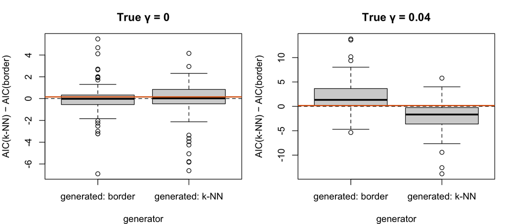

```r
op <- par(mfrow = c(1, 2), mar = c(4, 4, 3, 1))
for (g in params$cross_gammas) {
  d <- cross[cross$true_gamma == g, ]
  boxplot(aic_knn - aic_border ~ generator, d,
          names = c("generated: border", "generated: k-NN"),
          ylab = "AIC(k-NN) − AIC(border)",
          main = sprintf("True γ = %s", g))
  abline(h = 0, lty = 2)
  abline(h = pars$knn$aic - pars$border$aic, col = "#d95f02", lwd = 2)
}
```

```r
par(op)
```

Above 0 means border fits better. The orange line is the real data’s difference.

```r
cs <- cross |>
  group_by(generator, true_gamma) |>
  summarise(rb = mean(gamma_rank_p_border <= 0.05),
            rk = mean(gamma_rank_p_knn <= 0.05),
            right = if (first(generator) == "border") mean(aic_border < aic_knn)
                    else mean(aic_knn < aic_border),
            .groups = "drop")
b4 <- cs[cs$generator == "border" & cs$true_gamma == 0.04, ]
k4 <- cs[cs$generator == "knn" & cs$true_gamma == 0.04, ]
```

What this means:

- **The two networks overlap a lot:** 1024 of the 1248 border links are also k-NN links.
- **A placebo win does not say which network is right.** When border generated the data (γ = 0.04), k-NN still beat its placebos in 62% of datasets; when k-NN generated it, border beat its placebos in 72%. So the real result (both networks beat their placebos) tells us nearby regions matter, not which kind of neighbor.
- **The head-to-head AIC comparison picks the right network** in 77% (border true) and 82% (k-NN true) of datasets with γ = 0.04.
- **On the real data the two fit almost equally well** (AIC difference 0.2), well inside the range the simulation produces under either truth. The data do not distinguish shared borders from plain closeness.